# AirBnb analysis

Seung-Gyeom Evan KIM

April 08, 2023

## I. Price per arrondissement and visit frequencies

## II. Relationship of price per feature of appartment

## III. Number of hosting appartments per host

Necessary libraries and Data loading.

```r
library(dplyr)
library(lubridate)
```

```r
library(ggplot2)
library(scales)
library(tidyr)
```

```r
load("/Users/evan/Documents/A/DSTI/8_R_Bigdata/Exam/AirBnB.Rdata")
dim(L)
```

```
## [1] 52725    95
```

```r
dim(R)
```

```
## [1] 663599      2
```

```r
sum(is.na(L))
```

```
## [1] 279634
```

```r
sum(is.na(R))
```

```
## [1] 0
```

It requires careful attention to verify data for every procedure. Ensure that there are no duplicate row according to id.

```r
as.data.frame(unique(L$id))%>%
arrange(unique(L$id))
```

id ordered by frequency

```r
as.data.frame(table(L$id))%>%
arrange(desc("freq"))
```

id in descending order by frequency

```r
arrange(as.data.frame(table(L$id)))
```

There are no anomalous data; the total number of rows matches that of the unique function and table. Additionally, every frequency is less than 2, ensuring that there are no duplicated IDs

## I-1. Price per arrondissement and visit frequencies

### I-1.a. Examine the dataset

```r
sum(is.na(L$zipcode))
```

```
## [1] 0
```

```r
exam_zipcode = as.data.frame(table(L$zipcode))
names(exam_zipcode) <- c("zipcode", "frequency")
arrange(exam_zipcode)
```

> There may be empty values that do not show up when using the sum(is.na()) function, possibly because they are represented as black spaces ” “.

### I-1.b. Understand length of blank

```r
nchar(exam_zipcode[1, ])
```

```
##   zipcode frequency
##         1         3
```

```r
nchar(exam_zipcode[2, ])
```

```
##   zipcode frequency
##         1         1
```

> It appears that two diffrent black rows filtered by frequnecy but they have only one length.

#### I-1.c. Display the error data

```r
search_values = c("75019\n75019", "75014\n75014", "75011 PARIS", "750109", "750016", "75000", "75 018", "74000", "7009", "700014", "Paris", "75", "adf", "", "75106", "7517", "75522", "78008", "79019")

matching_zipcodes = L$zipcode %in% search_values
matching_zipcodes_data = L[matching_zipcodes, ]
select(matching_zipcodes_data, id, zipcode, street)%>%
  arrange(desc(zipcode))
```

> In order to modify the error values, create a vector named ‘search_values’. Using ‘%in%’ allows referencing zipcode data from ‘L$zipcode’ and returns a binary value. As this is a binary function, it is possible to create a new data frame to display the searched data. The empty operator, such as ‘[matching_zipcodes, ]’, necessitates quoting every searched row based on the zip codes.

### I-1.d. Modify the error values

```r
L$zipcode[27069] <- "75004"
L$zipcode[48935] <- "75018"
L$zipcode[5455] <- "75019"
L$zipcode[6922] <- "75019"
L$zipcode[9270] <- "75009"
L$zipcode[9877] <- "75009"
L$zipcode[13930] <- "75018"
L$zipcode[14434] <- "75018"
L$zipcode[21407] <- "75018"
L$zipcode[25426] <- "75018"
L$zipcode[25973] <- "75018"
L$zipcode[27294] <- "75018"
L$zipcode[32287] <- "75018"
L$zipcode[32498] <- "75018"
L$zipcode[33738] <- "75018"
L$zipcode[34705] <- "75018"
L$zipcode[37295] <- "75018"
L$zipcode[41142] <- "75018"
L$zipcode[47566] <- "75018"
L$zipcode[51270] <- "75003"
L$zipcode[5325] <- "75019"
L$zipcode[25845] <- "75008"
L$zipcode[34527] <- "75016"
L$zipcode[42586] <- "75011"
L$zipcode[45474] <- "75017"
L$zipcode[49009] <- "75018"
```

> Effect the modification directly into the dataset to avoid loading extra unnecessary data frames.

```r
exam_zipcode = as.data.frame(table(L$zipcode))
names(exam_zipcode) <- c("zipcode", "frequency")
arrange(exam_zipcode)
```

> Succeeded in modifying error data, but 504 empty data still remain. Remarkably, without the creation of a new dataset, it wasn’t possible to validate the modification. Instead of creating a new dataset, it’s efficient to rerun the same code to recreate the original dataframe.

## I-2. Visit frequency per arrondissement and month.

### I-2.a. Create a data frame named ‘Visit’ using the right_join function to count the number of listing IDs based on the zip code and month.

```r
Visit <- right_join(select(L, id, zipcode), R, by = c("id" = "listing_id"))

Visit$date <- as.Date(Visit$date)
Visit <- Visit %>%
  mutate(month = month(date))

Visit$zipcode <- as.numeric(as.character(Visit$zipcode))
Paris <- Visit %>%
  filter(zipcode >= 75001 & zipcode <= 75020)
Paris$zipcode <- as.numeric(as.character(Paris$zipcode))

Paris
```

### I-2-b. Check the missing values

```r
sum(is.na(Paris))
```

```
## [1] 0
```

```r
sum(is.na(Paris$id))
```

```
## [1] 0
```

```r
sum(is.na(Paris$zipcode))
```

```
## [1] 0
```

```r
sum(is.na(Paris$date))
```

```
## [1] 0
```

```r
sum(is.na(Paris$month))
```

```
## [1] 0
```

### I-2-c. Summary for the frequencies of visits by arrondissement

```r
summary(as.data.frame(table(Paris$zipcode))%>% arrange(desc("freq")))
```

```
##       Var1         Freq
##  75001  : 1   Min.   :12704
##  75002  : 1   1st Qu.:22037
##  75003  : 1   Median :30392
##  75004  : 1   Mean   :32167
##  75005  : 1   3rd Qu.:40366
##  75006  : 1   Max.   :72704
##  (Other):14
```

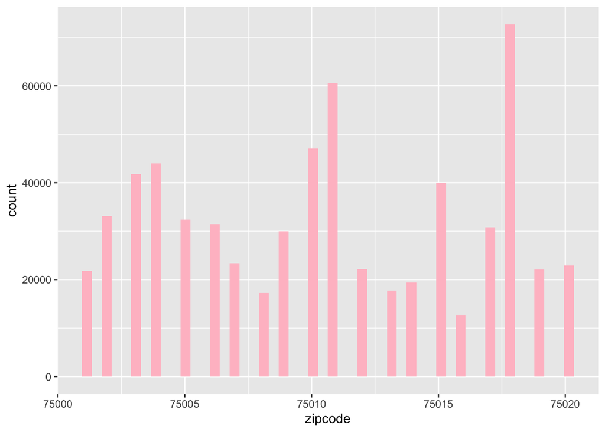

```r
ggplot(data = Paris) +
  geom_histogram(aes(x = zipcode),bins=50,fill="pink")
```

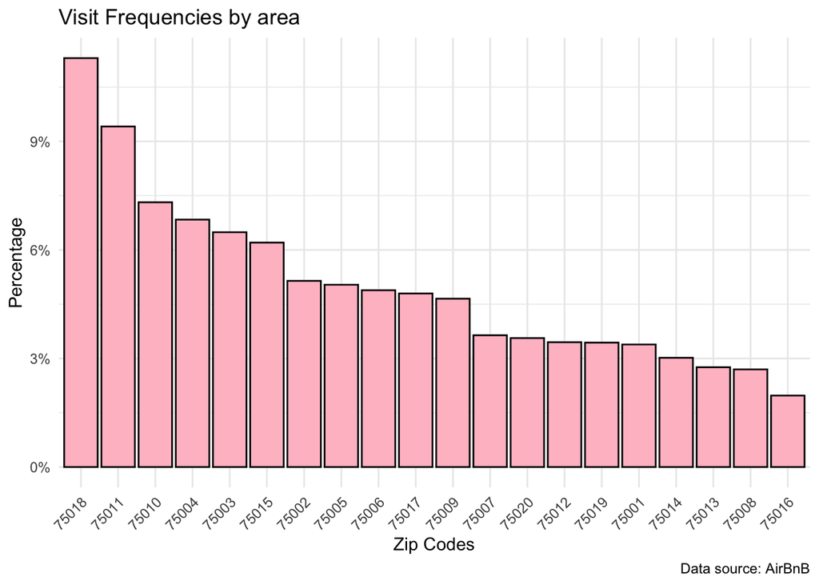

```r
Paris.percent <- table(Paris$zipcode) / nrow(Paris)

Paris$zipcode <- factor(Paris$zipcode, levels = names(sort(Paris.percent, decreasing = TRUE)))

ggplot(Paris, aes(x = zipcode)) +
  geom_bar(aes(y = (..count..)/sum(..count..)), fill = "pink", color = "black") +
  scale_y_continuous(labels = scales::percent_format()) +
  labs(
    title = "Visit Frequencies by area",
    x = "Zip Codes",
    y = "Percentage",
    caption = "Data source: AirBnB"
  ) +
  theme_minimal(base_size = 11) +
  theme(
    axis.text.x = element_text(angle = 45, hjust = 1)
  )
```

> The most popular area for AirBnB guests seems to be Paris’s 18th arrondissement and, conversely, the 16th arrondissement.

### I-2-b. Summary for the frequencies of visits by month

```r
summary(as.data.frame(table(Paris$month))%>% arrange(desc("freq")))
```

```
##       Var1        Freq
##  1      :1   Min.   :36195
##  2      :1   1st Qu.:40298
##  3      :1   Median :48682
##  4      :1   Mean   :53612
##  5      :1   3rd Qu.:58755
##  6      :1   Max.   :93022
##  (Other):6
```

> The least number of visits is 36,195, and the maximum number of visits is 93,022. The coverage is about 2.6 times. Generally, we can say that there should be around 53,612 visits every month as the average number of visits each month. However, verification over the years will be required to make more precise predictions.

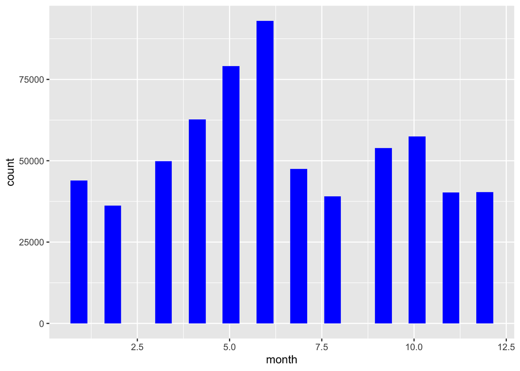

```r
ggplot(data = Paris) +
  geom_histogram(aes(x = month),bins=25,fill="blue")
```

> In Spring and Autom there are more visits than the other seasons.

## I-3. Prcie per arrondissement

### I-3.a. Create a new data frame and ensure the data

```r
L$price <- as.numeric(gsub("[\\$,]", "", L$price))

Quarters = select(L, id, price, zipcode)

Quarters$zipcode <- as.numeric(as.character(Quarters$zipcode))

Price.Paris = Quarters %>%
  filter(zipcode >= 75001 & zipcode <= 75020)
Price.Paris$zipcode <- as.character(Price.Paris$zipcode)

Price.Paris = arrange(Price.Paris, desc(price))
Price.Paris
```

### I-3.b. check the number of missing values

```r
sum(is.na(Price.Paris))
```

```
## [1] 0
```

> However, there are no blank values except for 2 zero prices. one of these is a test data, consequently, it doesn’t need to be present.

### I-3.c. Summary based on the price and zipcode

```r
summary(Price.Paris$price)
```

```
##    Min. 1st Qu.  Median    Mean 3rd Qu.    Max.
##    0.00   55.00   75.00   95.66  108.00 6081.00
```

```r
sd(Price.Paris$price)
```

```
## [1] 88.44185
```

### I-3.d. Visualization of trend of rental price

```r
par(Price.Paris)
```

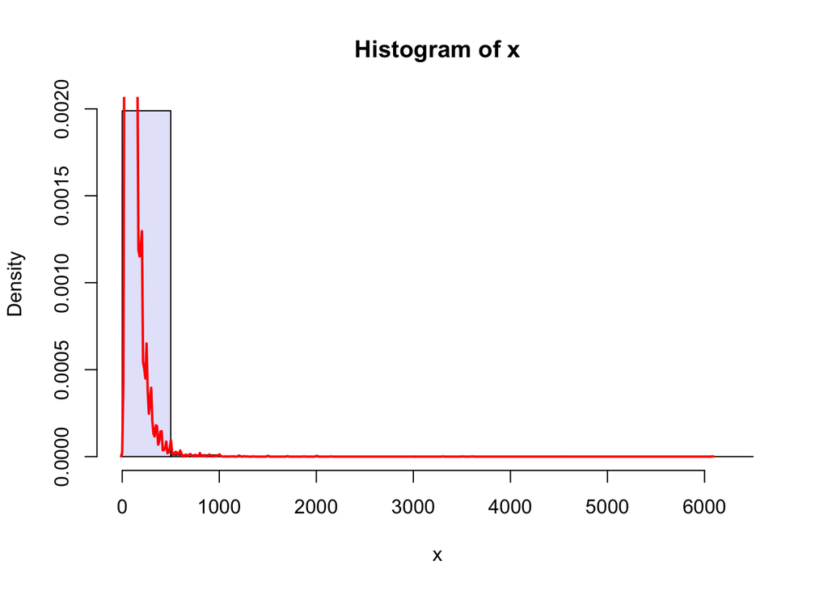

```r
x = Price.Paris$price
hist(x,col='lavender',freq=FALSE)
lines(density(x),lwd=2,col='red')
```

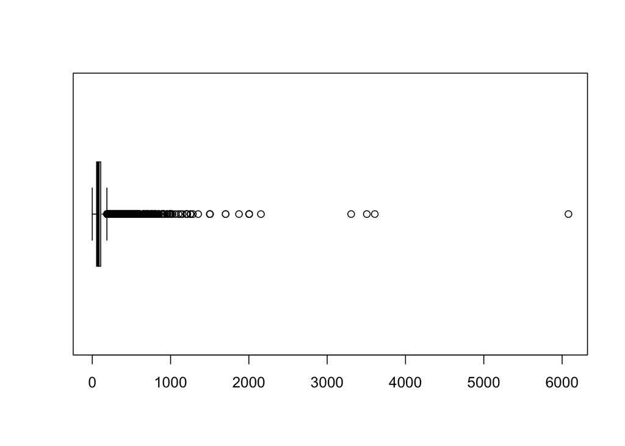

```r
boxplot(x,col='lavender',horizontal = TRUE)
```

> The density of price shows how the price data is scattered.

Less than 500 dollors

```r
filtered_data <- Price.Paris %>%
  filter(price < 500)
```

```r
par(filtered_data)
```

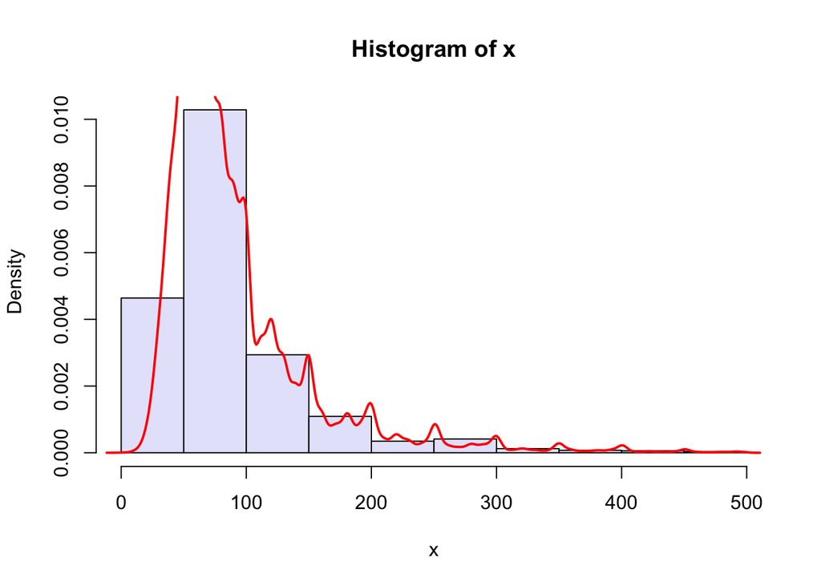

```r
x = filtered_data$price
hist(x,col='lavender',freq=FALSE)
lines(density(x),lwd=2,col='red')
```

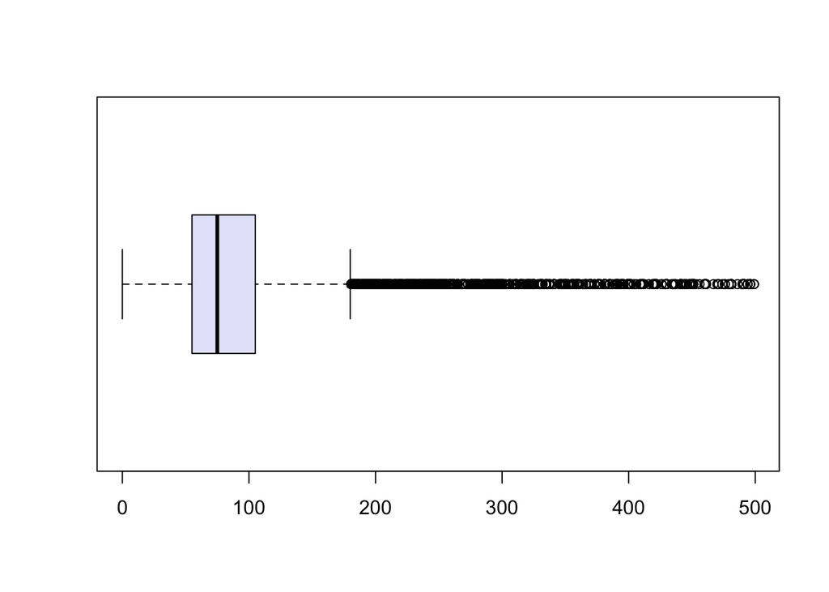

```r
boxplot(x,col='lavender',horizontal = TRUE)
```

> After removing the outliers, it shows more readable graphical data.

### I-3.d. Trend of price per arrondissement

```r
Price.Paris.grouped = group_by(Price.Paris, zipcode)
  Summ_price = summarise(Price.Paris.grouped,
                price_mean = mean(price, na.rm = TRUE),
                price_sd = sd(price, na.rm = TRUE))
  Summ_price
```

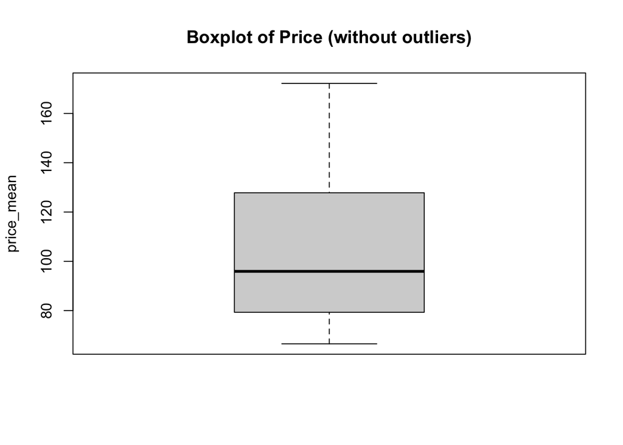

```r
Q1 <- quantile(Summ_price$price_mean, 0.25)
Q3 <- quantile(Summ_price$price_mean, 0.75)
IQR <- Q3 - Q1

lower_bound <- Q1 - 1.5 * IQR
upper_bound <- Q3 + 1.5 * IQR
outliers <- Summ_price$price_mean[Summ_price$price_mean < lower_bound | Summ_price$price_mean > upper_bound]

Price_mean_noOutliers <- Summ_price[!Summ_price$price_mean %in% outliers, ]

boxplot(Price_mean_noOutliers$price_mean,
main = "Boxplot of Price (without outliers)",
ylab = "price_mean")
```

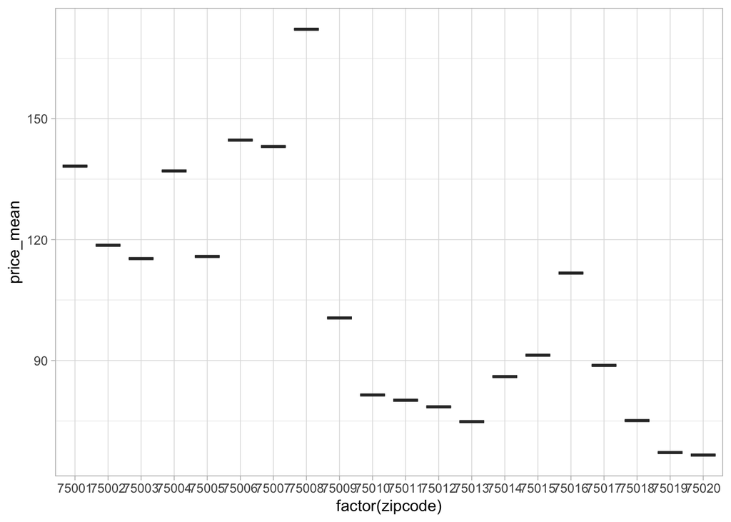

```r
ggplot(data = Price_mean_noOutliers) +
  theme_light() +
  geom_boxplot(aes(x = factor(zipcode), y = price_mean))
```

> To understand better the phenomene of rental pricing, comparing the frequencies of visits per arrondissement and price would be interesting.

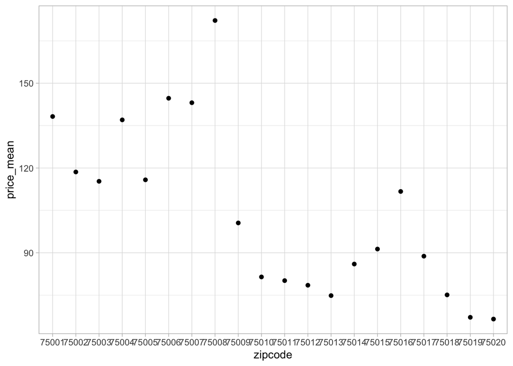

```r
  ggplot(data = Summ_price) + theme_light() +
  geom_point(aes(x = zipcode,y = price_mean)) +
  geom_smooth(aes(x = zipcode,y = price_mean))
```

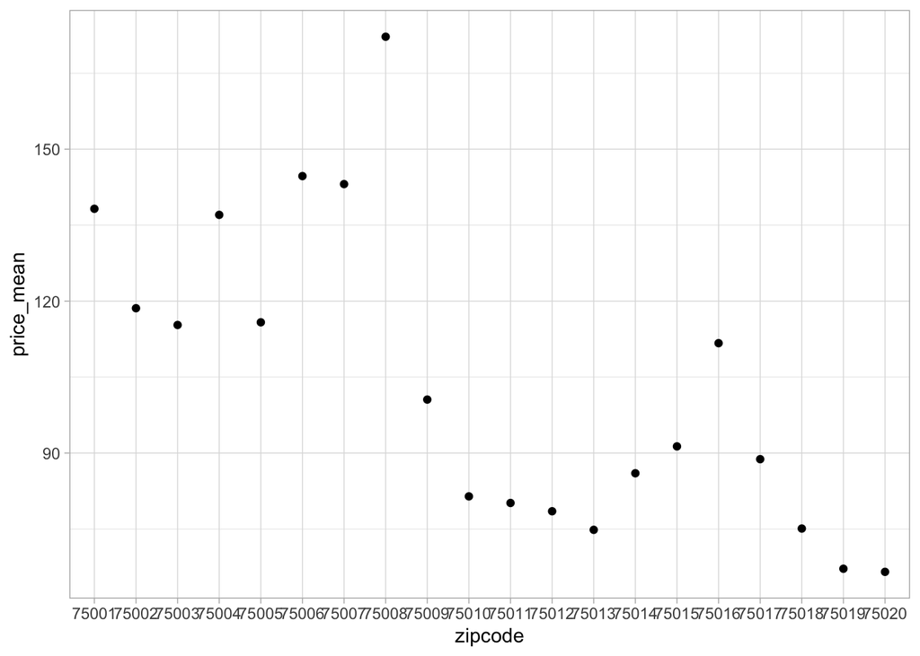

```r
filtered_meanPrice = Summ_price %>%
filter(price_mean < 1000)
  ggplot(data = filtered_meanPrice) + theme_light() +
  geom_point(aes(x = zipcode,y = price_mean)) +
  geom_smooth(aes(x = zipcode,y = price_mean))
```

> nother indicator to prove there is a significant gap between majority prices and minority prices is the presence of diverse reasons behind the rental pricing.

## II-1. Relationship of price per feature of appartment

### II-1.a. Create a new data frame and verify the missing values

```r
Features <- L %>%
  filter(property_type == "Apartment") %>%
  select(id, property_type, room_type, bed_type, accommodates, bedrooms, beds, price)
Features$price <- as.numeric(gsub("[\\$,]", "", Features$price))
Features
```

```r
sum(is.na(Features$id))
```

```
## [1] 0
```

```r
sum(is.na(Features$property_type))
```

```
## [1] 0
```

```r
sum(is.na(Features$room_type))
```

```
## [1] 0
```

```r
sum(is.na(Features$accommodates))
```

```
## [1] 0
```

```r
sum(is.na(Features$bedrooms))
```

```
## [1] 189
```

```r
sum(is.na(Features$beds))
```

```
## [1] 75
```

```r
sum(is.na(Features$bed_type))
```

```
## [1] 0
```

> there few of missing values

### II-1.b. Average price data frame

```r
 avg_price <- Features %>%
  group_by(accommodates, bedrooms, room_type, bed_type) %>%
  summarise(avg_price = mean(price, na.rm = TRUE), .groups = 'drop') %>%
  ungroup()

Features_with_avg_price <- merge(Features, avg_price, by = c("accommodates", "bedrooms", "room_type", "bed_type"))
avg_price
```

### II-1.c. Number of bedrooms and Room Type

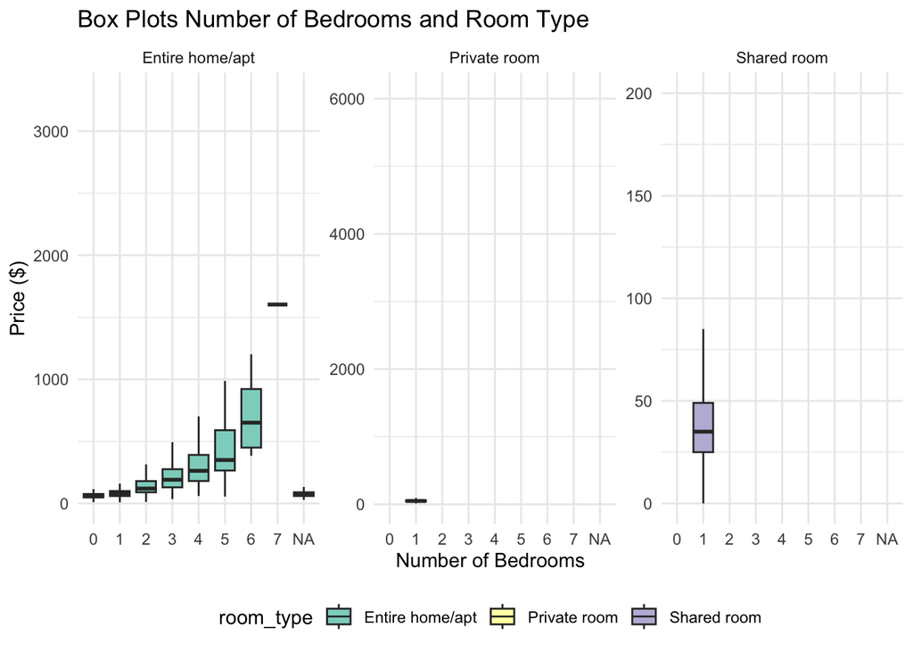

```r
ggplot(Features, aes(x = factor(bedrooms), y = price, fill = room_type)) +
  geom_boxplot(outlier.shape = NA) +
  facet_wrap(~room_type, scales = "free_y") +
  theme_minimal() +
  labs(title = "Box Plots Number of Bedrooms and Room Type",
       x = "Number of Bedrooms",
       y = "Price ($)") +
  scale_fill_brewer(palette = "Set3") +
  theme(legend.position = "bottom")
```

> The number of Entire home/apt is the highest, in terms of price. The number of bedrooms has an impact on increasing the rental price. Secondly, the private room has a higher price structure than the shared room.

### II-1.d. Number of beds room and Room type

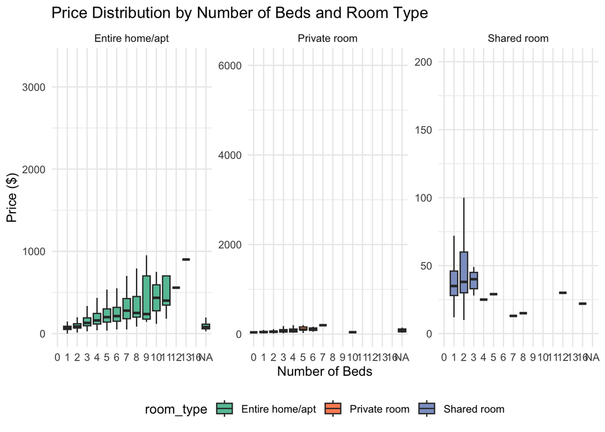

```r
# Box plot for price distribution by number of beds and room type
ggplot(Features, aes(x = factor(beds), y = price, fill = room_type)) +
  geom_boxplot(outlier.shape = NA) +
  facet_wrap(~room_type, scales = "free_y") +
  theme_minimal() +
  labs(title = "Price Distribution by Number of Beds and Room Type",
       x = "Number of Beds",
       y = "Price ($)") +
  scale_fill_brewer(palette = "Set2") +
  theme(legend.position = "bottom")
```

### II-1.e. Number of Accommodates and Room type

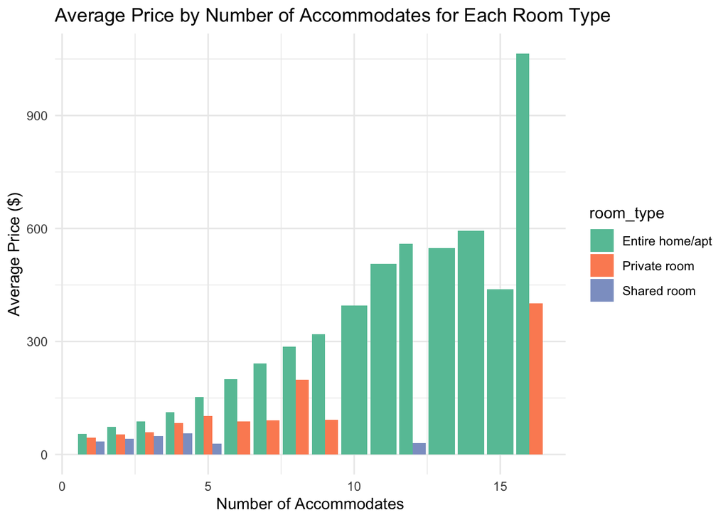

```r
avg_price_by_accommodates <- Features %>%
  group_by(accommodates, room_type) %>%
  summarise(mean_price = mean(price, na.rm = TRUE), .groups = 'drop')

ggplot(avg_price_by_accommodates, aes(x = accommodates, y = mean_price, fill = room_type)) +
  geom_bar(stat = "identity", position = position_dodge()) +
  theme_minimal() +
  labs(title = "Average Price by Number of Accommodates for Each Room Type",
       x = "Number of Accommodates",
       y = "Average Price ($)") +
  scale_fill_brewer(palette = "Set2")
```

### II-1.f. Bed type and Room type

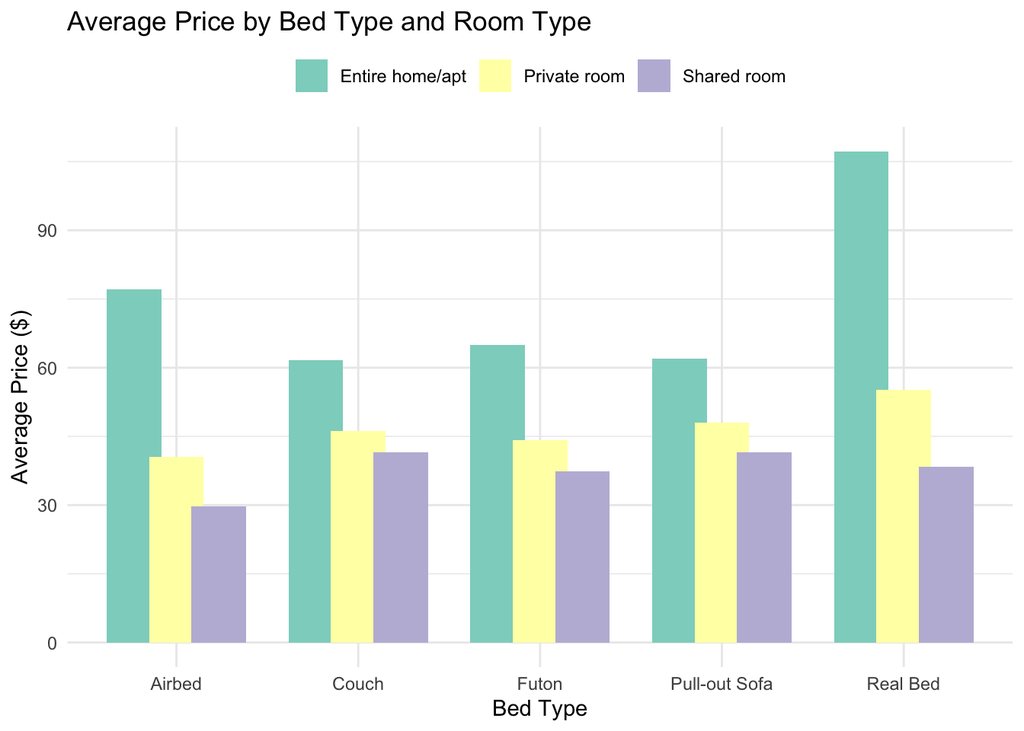

```r
avg_price_by_bedtype_and_room <- Features %>%
  group_by(bed_type, room_type) %>%
  summarise(mean_price = mean(price, na.rm = TRUE), .groups = 'drop')

ggplot(avg_price_by_bedtype_and_room, aes(x = bed_type, y = mean_price, fill = room_type)) +
  geom_bar(stat = "identity", position = position_dodge(width = 0.7)) +
  theme_minimal() +
  labs(title = "Average Price by Bed Type and Room Type",
       x = "Bed Type",
       y = "Average Price ($)") +
  scale_fill_brewer(palette = "Set3") +
  theme(legend.title = element_blank(), legend.position = "top")
```

## III-1. Number of appartement per Host

### III-1.a. Data cleaning Hosts

```r
Hosts <- L %>%
  select(id, host_id, property_type) %>%
  filter(property_type == "Apartment")
Hosts
```

```r
sum(is.na(Hosts))
```

```
## [1] 0
```

```r
exam_Hosts = as.data.frame(table(Hosts$host_id))
names(exam_Hosts) <- c("host_id", "frequency")
exam_Hosts <- arrange(exam_Hosts, desc(frequency))
exam_Hosts
```

> There is no anomaly data

### III-1.b. Count number of rental appartment per host.

```r
summary(exam_Hosts)
```

```
##     host_id        frequency
##  2626   :    1   Min.   :  1.000
##  2883   :    1   1st Qu.:  1.000
##  3631   :    1   Median :  1.000
##  4175   :    1   Mean   :  1.171
##  6792   :    1   3rd Qu.:  1.000
##  7749   :    1   Max.   :152.000
##  (Other):43255
```

> Most hosts rent only one apartment, which seems quite scattered due to the maximum count number. However, there is a notable exception, with one host having more than 100 hosting apartments.

> The exact maximum number of apartments is 152 for one host; otherwise, the majority of hosts have only one rental apartment.

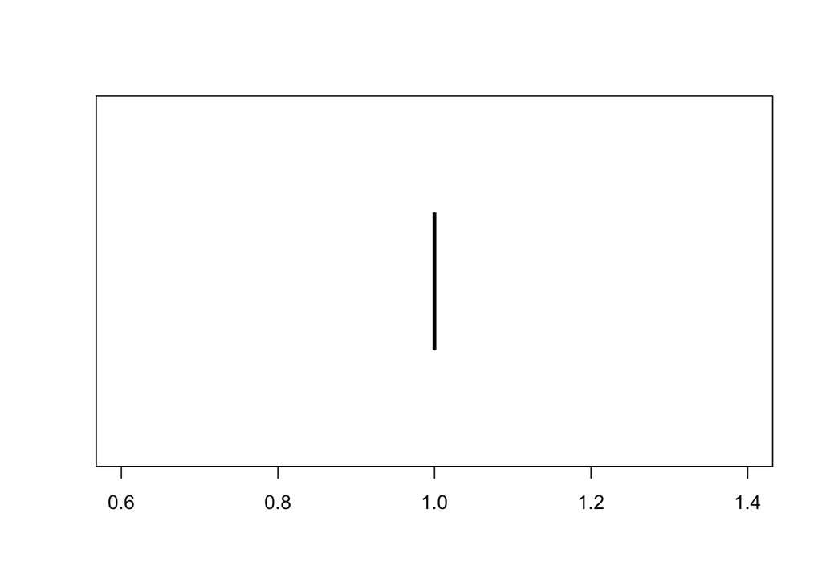

```r
boxplot(exam_Hosts$frequency, col = 'lavender', horizontal = TRUE, outline = FALSE)
```

### III-1.c. Understand the proportion of rented apartment numbers..

```r
count1 <- exam_Hosts %>%
  filter(frequency < 2) %>%
  count()

count2 <- exam_Hosts %>%
  filter(frequency > 1 & frequency < 51) %>%
  count()

count3 <- exam_Hosts %>%
  filter(frequency > 50) %>%
  count()

count.combined <- rbind(count1, count2, count3)

rownames(count.combined) <- c("Nb APT < 2", "1 < Nb APT < 51", "Nb APT > 50")

count.combined$Percentage <- count.combined$n / sum(count.combined$n) * 100

print(count.combined)
```

```
##                     n  Percentage
## Nb APT < 2      40209 92.94514690
## 1 < Nb APT < 51  3037  7.02017984
## Nb APT > 50        15  0.03467326
```

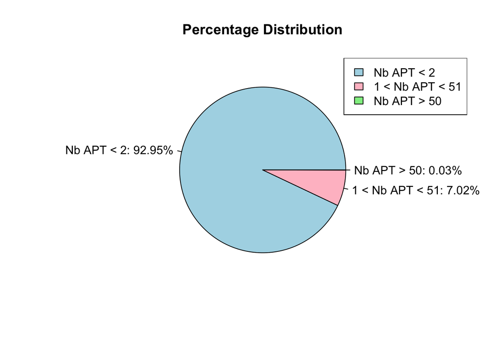

```r
pie_labels <- paste0(rownames(count.combined), ": ", round(count.combined$Percentage, 2), "%")

pie(count.combined$Percentage,
    labels = pie_labels,
    col = c('lightblue', 'pink', 'lightgreen'),
    main = "Percentage Distribution")

legend("topright",
       legend = rownames(count.combined),
       fill = c('lightblue', 'pink', 'lightgreen'))
```